# 1st Assignment

Ignacio Ruperez & Federico Garcia (team name Slowly). Ranking 1514. Score 0.13086

# Data Reading and preparation

First of all, we need to upload the data sets: training and test.

## Intro

```r
train = read.csv("train.csv")
test = read.csv("test.csv")
```

We check for duplicates and remove the ID Column, since it is not relevant for our analysis.

```r
length(unique(train$Id)) == nrow(train)
```

```
## [1] TRUE
```

There are no duplicates so we remove Id column and we combine both datasets to make the data processing easier. We must also remove SalePrice (our target variable) since it is not present in the test set.

```r
test1 = read.csv("test.csv")

train1 = read.csv("train.csv")
train2 = within(train, rm('Id', 'SalePrice'))
test = within(test, rm('Id'))

both = rbind(train2, test)
```

## Dealing with missing values

Our dataset is filled with many missing values, therefore, before we can build any predictive model we’ll clean our data by filling in all NA’s with appropriate values.

```r
na.cols <- which(colSums(is.na(both)) > 0)
sort(colSums(sapply(both[na.cols], is.na)), decreasing = TRUE)
```

```
##       PoolQC  MiscFeature        Alley        Fence  FireplaceQu
##         2909         2814         2721         2348         1420
##  LotFrontage  GarageYrBlt GarageFinish   GarageQual   GarageCond
##          486          159          159          159          159
##   GarageType     BsmtCond BsmtExposure     BsmtQual BsmtFinType2
##          157           82           82           81           80
## BsmtFinType1   MasVnrType   MasVnrArea     MSZoning    Utilities
##           79           24           23            4            2
## BsmtFullBath BsmtHalfBath   Functional  Exterior1st  Exterior2nd
##            2            2            2            1            1
##   BsmtFinSF1   BsmtFinSF2    BsmtUnfSF  TotalBsmtSF   Electrical
##            1            1            1            1            1
##  KitchenQual   GarageCars   GarageArea     SaleType
##            1            1            1            1
```

```r
paste('There are', length(na.cols), 'columns with missing values')
```

```
## [1] "There are 34 columns with missing values"
```

There are 34 columns with NA values. Let’s find the best way of imputing them by analyzing each of these variables.

### PoolQC

```r
sum(both$PoolArea > 0)
```

```
## [1] 13
```

```r
both %>%
  filter(PoolArea > 0) %>%
  select(PoolQC, PoolArea)
```

```
##    PoolQC PoolArea
## 1      Ex      512
## 2      Fa      648
## 3      Gd      576
## 4      Ex      555
## 5      Gd      480
## 6      Fa      519
## 7      Gd      738
## 8      Ex      144
## 9    <NA>      368
## 10   <NA>      444
## 11     Ex      228
## 12   <NA>      561
## 13     Gd      800
```

```r
both$PoolQC = factor(both$PoolQC, levels=c(levels(both$PoolQC), "No"))
both$PoolQC[is.na(both$PoolQC)] = "No"
```

Further in the analysis we will evaluate if we should create a dummy variable Pool: Yes/No if we see that this has an influence on the sale price.

### MiscFeature

There are 2814 missing values of this variable. According to the data explanation, NA stands for none.

```r
both$MiscFeature = factor(both$MiscFeature,levels=c(levels(both$MiscFeature), "No"))
both$MiscFeature[is.na(both$MiscFeature)] = "No"
```

### Alley

According to data explanations, NA corresponds to no alley.

```r
both$Alley = factor(both$Alley, levels=c(levels(both$Alley), "None"))
both$Alley[is.na(both$Alley)] = "None"
```

### Fence

According to data explanations, NA corresponds to no fence.

```r
both$Fence = factor(both$Fence, levels=c(levels(both$Fence), "No"))
both$Fence[is.na(both$Fence)] = "No"
```

### Fireplace

According to data explanations, NA corresponds to no fireplace.

```r
both$FireplaceQu = factor(both$FireplaceQu, levels=c(levels(both$FireplaceQu), "No"))
both$FireplaceQu[is.na(both$FireplaceQu)] = "No"
```

### LotFrontage

LotFrontage is the linear feet of street connected to property. Since there are many empty values, we may use LotArea to fill in these values. There seems to be a correlation between LotFrontage and LotArea, so we estimate LotFrontage from a linear regression with LotArea.

```r
lotest3 = both %>%
  select(LotArea, LotFrontage) %>%
  filter(!is.na(LotFrontage))

cor(lotest3$LotArea, lotest3$LotFrontage)
```

```
## [1] 0.4898956
```

```r
# We calculate the quantiles to erase the outliers
quantile(lotest3$LotArea, 0.95)
```

```
##   95%
## 16143
```

```r
quantile(lotest3$LotFrontage, 0.95)
```

```
## 95%
## 107
```

```r
# We obtain the linear relation between LotArea and Lotest
lotest4 = lotest3 %>%
  group_by(LotArea, LotFrontage) %>%
  filter(LotArea < 16000, LotFrontage < 107)

cor(lotest4$LotArea, lotest4$LotFrontage)
```

```
## [1] 0.7088062
```

```r
f <- lm(data = lotest4, LotFrontage ~ LotArea)

both$LotFrontage[is.na(both$LotFrontage)] <- both$LotArea[is.na(both$LotFrontage)] * f$coefficients[2] + f$coefficients[1]
```

### Garage

We check if missing values for features that describe garages are due to the fact that those houses do not have a garage. The variable that determines this is GarageType. So 157 NAs in GarageType can be transformed to none. We can do the same with GarageCars and GarageArea.

We check if all 157 NAs in GarageType correspond to all NAs in GarageYrBlt, GarageFinish, GarageQual and GarageCond (159 each).

```r
both %>%
  group_by(GarageYrBlt, GarageType) %>%
  summarize(count = n()) %>%
  filter(is.na(GarageYrBlt), is.na(GarageType)) %>%
  .$count
```

```
## [1] 157
```

```r
both %>%
  group_by(GarageFinish, GarageType) %>%
  summarize(count = n()) %>%
  filter(is.na(GarageFinish), is.na(GarageType)) %>%
  .$count
```

```
## [1] 157
```

```r
both %>%
  group_by(GarageQual, GarageType) %>%
  summarize(count = n()) %>%
  filter(is.na(GarageQual), is.na(GarageType)) %>%
  .$count
```

```
## [1] 157
```

```r
both %>%
  group_by(GarageCond, GarageType) %>%
  summarize(count = n()) %>%
  filter(is.na(GarageCond), is.na(GarageType)) %>%
  .$count
```

```
## [1] 157
```

```r
# Categorial
both$GarageType = factor(both$GarageType, levels=c(levels(both$GarageType), "No"))
both$GarageType[is.na(both$GarageType)] = "No"

both$GarageFinish = factor(both$GarageFinish, levels=c(levels(both$GarageFinish), "No"))
both$GarageFinish[is.na(both$GarageFinish)] = "No"

both$GarageQual = factor(both$GarageQual, levels=c(levels(both$GarageQual), "No"))
both$GarageQual[is.na(both$GarageQual)] = "No"

both$GarageCond = factor(both$GarageCond, levels=c(levels(both$GarageCond), "No"))
both$GarageCond[is.na(both$GarageCond)] = "No"

# Numerical
both$GarageYrBlt[is.na(both$GarageYrBlt)] = 0
both$GarageArea[is.na(both$GarageArea)] = 0
both$GarageCars[is.na(both$GarageCars)] = 0
```

On the other hand, by taking a look at GarageYear stats, we see that the maximum year is 2207. Since this makes no sense, we will assume it means 2007.

```r
summary(both$GarageYrBlt)
```

```
##    Min. 1st Qu.  Median    Mean 3rd Qu.    Max.
##       0    1957    1977    1870    2001    2207
```

```r
both$GarageYrBlt[both$GarageYrBlt==2207] = 2007
```

### Basement features

There are 11 Basement features and the NAs in them are different. For Qual, Cond, Exposure, FinType1 and FinType 2 (the features with the highest number of NA), data description states that NA = no basement. We will fill NAs in numeric values with ‘0’.

```r
both$BsmtQual = factor(both$BsmtQual, levels=c(levels(both$BsmtQual), "No"))
both$BsmtQual[is.na(both$BsmtQual)] = "No"

both$BsmtCond = factor(both$BsmtCond, levels=c(levels(both$BsmtCond), "No"))
both$BsmtCond[is.na(both$BsmtCond)] = "No"

#both$BsmtExposure = factor(both$BsmtExposure,levels=c(levels(both$BsmtExposure), "No"))
both$BsmtExposure[is.na(both$BsmtExposure)] = "No"

both$BsmtFinType1 = factor(both$BsmtFinType1, levels=c(levels(both$BsmtFinType1), "No"))
both$BsmtFinType1[is.na(both$BsmtFinType1)] = "No"

both$BsmtFinType2 = factor(both$BsmtFinType2, levels=c(levels(both$BsmtFinType2), "No"))
both$BsmtFinType2[is.na(both$BsmtFinType2)] = "No"

both$BsmtFinSF1[is.na(both$BsmtFinSF1)] = 0
both$BsmtFinSF2[is.na(both$BsmtFinSF2)] = 0
both$BsmtUnfSF[is.na(both$BsmtUnfSF)] = 0
both$TotalBsmtSF[is.na(both$TotalBsmtSF)] = 0
both$BsmtFullBath[is.na(both$BsmtFullBath)] = 0
both$BsmtHalfBath[is.na(both$BsmtHalfBath)] = 0
```

### Masonry

There is a category “None” so we’ll assume that empty rows are None for categorical and 0 for numerical.

```r
both$MasVnrType[is.na(both$MasVnrType)] = "None"
both$MasVnrArea[is.na(both$MasVnrArea)] = 0
```

### All the remaining 8 columns

```r
#MSZoning: we have four NA left so we will substitute them for the most common category (RL).

both %>%
  group_by(MSZoning) %>%
  summarise(counter = n())
```

```
## # A tibble: 6 x 2
##   MSZoning counter
##   <fct>      <int>
## 1 C (all)       25
## 2 FV           139
## 3 RH            26
## 4 RL          2265
## 5 RM           460
## 6 <NA>           4
```

```r
both$MSZoning[is.na(both$MSZoning)] = "RL"


#Utilities: since all utilities are type AllPub (this means "All Public Utilities") except one, we will drop this column

both = both %>%
  select(-Utilities)

#Functional: we have 2 NA left that we will substitute by the most frequent category (Typ)

both %>%
  group_by(Functional) %>%
  summarise(counter = n())
```

```
## # A tibble: 8 x 2
##   Functional counter
##   <fct>        <int>
## 1 Maj1            19
## 2 Maj2             9
## 3 Min1            65
## 4 Min2            70
## 5 Mod             35
## 6 Sev              2
## 7 Typ           2717
## 8 <NA>             2
```

```r
both$Functional[is.na(both$Functional)] = "Typ"

#Exterior1st: we will substitute the remainer with most frequent value (Vinylsd)

both %>%
  group_by(Exterior1st) %>%
  summarise(counter = n())
```

```
## # A tibble: 16 x 2
##    Exterior1st counter
##    <fct>         <int>
##  1 AsbShng          44
##  2 AsphShn           2
##  3 BrkComm           6
##  4 BrkFace          87
##  5 CBlock            2
##  6 CemntBd         126
##  7 HdBoard         442
##  8 ImStucc           1
##  9 MetalSd         450
## 10 Plywood         221
## 11 Stone             2
## 12 Stucco           43
## 13 VinylSd        1025
## 14 Wd Sdng         411
## 15 WdShing          56
## 16 <NA>              1
```

```r
both$Exterior1st[is.na(both$Exterior1st)] = "VinylSd"

# Exterior2nd: we do the same as in the previous category

both %>%
  group_by(Exterior2nd) %>%
  summarise(counter = n())
```

```
## # A tibble: 17 x 2
##    Exterior2nd counter
##    <fct>         <int>
##  1 AsbShng          38
##  2 AsphShn           4
##  3 Brk Cmn          22
##  4 BrkFace          47
##  5 CBlock            3
##  6 CmentBd         126
##  7 HdBoard         406
##  8 ImStucc          15
##  9 MetalSd         447
## 10 Other             1
## 11 Plywood         270
## 12 Stone             6
## 13 Stucco           47
## 14 VinylSd        1014
## 15 Wd Sdng         391
## 16 Wd Shng          81
## 17 <NA>              1
```

```r
both$Exterior2nd[is.na(both$Exterior2nd)] = "VinylSd"

# Electrical: we substitute NA by the most common category

both %>%
  group_by(Electrical) %>%
  summarise(counter = n())
```

```
## # A tibble: 6 x 2
##   Electrical counter
##   <fct>        <int>
## 1 FuseA          188
## 2 FuseF           50
## 3 FuseP            8
## 4 Mix              1
## 5 SBrkr         2671
## 6 <NA>             1
```

```r
both$Electrical[is.na(both$Electrical)] = "SBrkr"

# KitchenQual

both %>%
  group_by(KitchenQual) %>%
  summarise(counter = n())
```

```
## # A tibble: 5 x 2
##   KitchenQual counter
##   <fct>         <int>
## 1 Ex              205
## 2 Fa               70
## 3 Gd             1151
## 4 TA             1492
## 5 <NA>              1
```

```r
both$KitchenQual[is.na(both$KitchenQual)] = "TA"

# SaleType

both %>%
  group_by(SaleType) %>%
  summarise(counter = n())
```

```
## # A tibble: 10 x 2
##    SaleType counter
##    <fct>      <int>
##  1 COD           87
##  2 Con            5
##  3 ConLD         26
##  4 ConLI          9
##  5 ConLw          8
##  6 CWD           12
##  7 New          239
##  8 Oth            7
##  9 WD          2525
## 10 <NA>           1
```

```r
both$SaleType[is.na(both$SaleType)] = "WD"
```

```r
na.cols <- which(colSums(is.na(both)) > 0)
paste('There are now', length(na.cols), 'columns with missing values')
```

```
## [1] "There are now 0 columns with missing values"
```

So we have no more NA columns

## Other data preparation

### Factorize features

```r
both$MSSubClass <- as.factor(both$MSSubClass)
both$MoSold <- as.factor(both$MoSold)
```

### Create new feature: Total Surface

Surface of a house is probably the most important variable when determining its price. Currently we do not have a Surface variable (it is splitted into two). So we create one with the sum of surface from basement, 1st floor and 2nd floor.

```r
both$TotalSF = both$TotalBsmtSF + both$X1stFlrSF + both$X2ndFlrSF
```

### Create new feature: New, remodeled or old house

Another variable that usually determines the price of a house is if it is first (new) or second hand, and if second hand, if it has been recently built or remodeled or not. Looking at the data, we are missing these variables.

The only variable related to this is a variable called YearRemodAdd that indicates the remodel date and is the same as construction date if no remodeling or additions have been made.

Therefore, we can create the following variables: - ageofhouse - yearsfromlastRemod

AGE OF HOUSE: to see how old the house is and NEWLY BUILT HOUSE: dummy to determine if the house is newly built

```r
both = both %>%
  mutate(Age = YrSold - YearBuilt, NewHouse = ifelse(Age <= 1, 1, 0))
```

YEARSLASTREMOD and RECENTLYREMOD

```r
both = both %>%
  mutate(Yearslastremod = YrSold - YearRemodAdd,
         Recentlyremod = ifelse(Yearslastremod < 1, 1, 0))
```

### Create new feature: Expensive and non expensive neighbourhoods

Where the house is located is another variable that usually has a big impact on the Sale Price. Currently, Neighborhoods are categorical variables that will not be included in our model.

```r
#We check differences in mean and median prices per area:

PriceAreas =train1 %>%
  select(Neighborhood, SalePrice) %>%
  group_by(Neighborhood) %>%
  summarise(median.price = median(SalePrice, na.rm = T), mean.price = mean(SalePrice)) %>%
  arrange(desc(mean.price))

PriceAreas
```

```
## # A tibble: 25 x 3
##    Neighborhood median.price mean.price
##    <fct>               <dbl>      <dbl>
##  1 NoRidge            301500     335295
##  2 NridgHt            315000     316271
##  3 StoneBr            278000     310499
##  4 Timber             228475     242247
##  5 Veenker            218000     238773
##  6 Somerst            225500     225380
##  7 ClearCr            200250     212565
##  8 Crawfor            200624     210625
##  9 CollgCr            197200     197966
## 10 Blmngtn            191000     194871
## # ... with 15 more rows
```

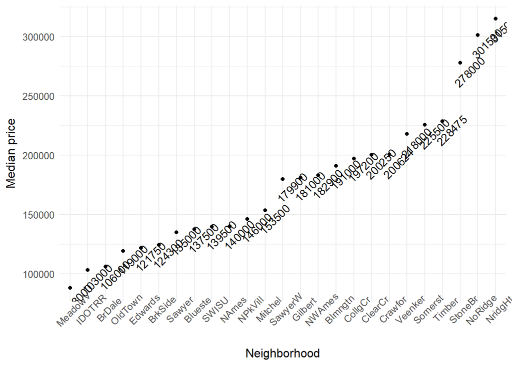

```r
# We can create four types of areas (Rich, Med, Poor) and create dummies. Or we can create a dummy for those houses that are int the top5 more expensive areas.

train1[,c('Neighborhood','SalePrice')] %>%
  group_by(Neighborhood) %>%
  summarise(median.price = median(SalePrice, na.rm = TRUE)) %>%
  arrange(median.price) %>%
  mutate(nb = factor(Neighborhood, levels=Neighborhood)) %>%
  ggplot(aes(x=nb, y=median.price)) +
  geom_point() +
  geom_text(aes(label = median.price, angle = 45), vjust = 2) +
  theme_minimal() +
  labs(x='Neighborhood', y='Median price') +
  theme(text = element_text(size=12),
        axis.text.x = element_text(angle=45))
```

```r
# According to the graph, we can differentiate four different types of price range.

nb_range <- c('MeadowV' = 'D', 'IDOTRR' = 'D', 'Sawyer' = 'D', 'BrDale' = 'C', 'OldTown' = 'C', 'Edwards' = 'C', 'BrkSide' = 'C', 'Blueste' = 'C', 'SWISU' = 'C', 'NAmes' = 'C', 'NPkVill' = 'C', 'Mitchel' = 'C', 'SawyerW' = 'B', 'Gilbert' = 'B', 'NWAmes' = 'B', 'Blmngtn' = 'B', 'CollgCr' = 'B', 'ClearCr' = 'B', 'Crawfor' = 'B', 'Veenker' = 'B', 'Somerst' = 'B', 'Timber' = 'B', 'StoneBr' = 'A', 'NoRidge' = 'A', 'NridgHt' = 'A')

nbD = c('MeadowV', 'IDOTRR', 'Sawyer')
nbC = c('BrDale', 'OldTown', 'Edwards', 'BrkSide', 'Blueste', 'SWISU', 'NAmes', 'NPkVill', 'Mitchel')
nbB = c('SawyerW', 'Gilbert', 'NWAmes', 'Blmngtn', 'CollgCr', 'ClearCr', 'Crawfor', 'Veenker', 'Somerst', 'Timber')
nbA = c('StoneBr', 'NoRidge', 'NridgHt')


both = both %>%
  mutate(NbType = ifelse(Neighborhood %in% nbD, 'D', ifelse(Neighborhood %in% nbC, 'C', ifelse (Neighborhood %in% nbB, 'B', ifelse (Neighborhood %in% nbA, 'A', "F")))))

both$NbType = as.factor(both$NbType)
```

### Transform categorical values to numeric

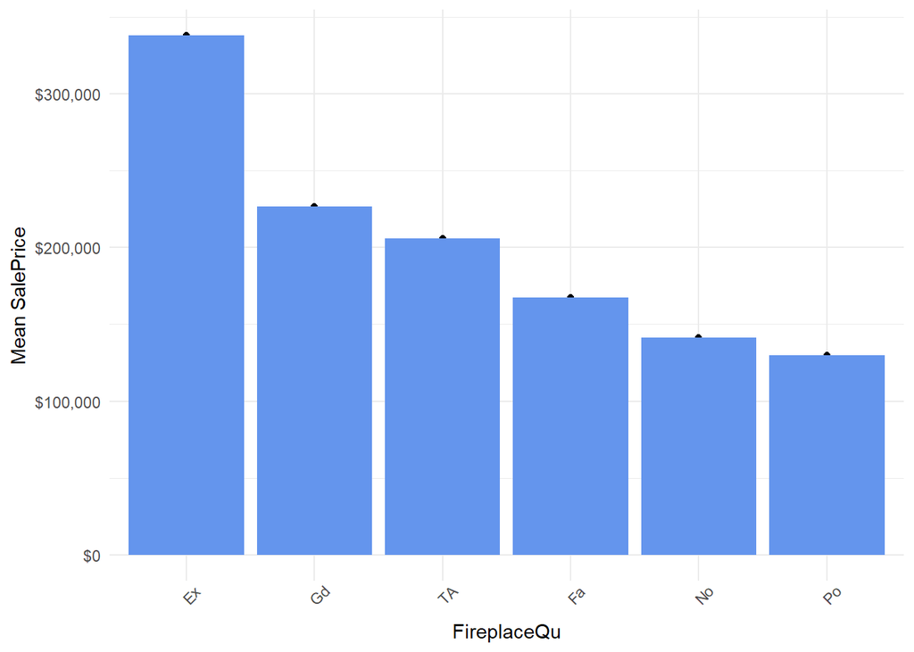

```
##   FireplaceQu mean.Quality mean.Price   n
## 1          Po         4.95   129764.1  20
## 2          No         5.46   141331.5 690
## 3          Fa         5.76   167298.5  33
## 4          TA         6.48   205723.5 313
## 5          Gd         6.89   226351.4 380
## 6          Ex         8.38   337712.5  24
```

```r
num_features <- names(which(sapply(both, is.numeric)))
cat_features <- names(which(sapply(both, is.character)))

both.numeric <- both[num_features]

group.both <- both[1:1460,]
group.both$SalePrice <- train$SalePrice

# Function that groups a column by its features and returns the median sale price for each unique feature

group.prices <- function(col) {
  group.table <- group.both[,c(col, 'SalePrice', 'OverallQual')] %>%
    group_by_(col) %>%
    summarise(mean.Quality = round(mean(OverallQual),2),
      mean.Price = mean(SalePrice), n = n()) %>%
    arrange(mean.Quality)

  print(qplot(x=reorder(group.table[[col]], -group.table[['mean.Price']]), y=group.table[['mean.Price']]) +
    geom_bar(stat='identity', fill='cornflowerblue') +
    theme_minimal() +
    scale_y_continuous(labels = dollar) +
    labs(x=col, y='Mean SalePrice') +
    theme(axis.text.x = element_text(angle = 45)))

  return(data.frame(group.table))
}

## Function to compute the mean overall quality for each quality

quality.mean <- function(col) {
  group.table <- both[,c(col, 'OverallQual')] %>%
    group_by_(col) %>%
    summarise(mean.qual = mean(OverallQual)) %>%
    arrange(mean.qual)

  return(data.frame(group.table))
}

# Function that maps a categoric value to its corresponding numeric value and returns that column to the data frame

map.fcn <- function(cols, map.list, df){
  for (col in cols){
    df[col] <- as.numeric(map.list[both[,col]])
  }
  return(df)
}

qual.cols <- c('ExterQual', 'ExterCond', 'GarageQual', 'GarageCond', 'FireplaceQu', 'KitchenQual', 'HeatingQC', 'BsmtQual')

group.prices('FireplaceQu')
```

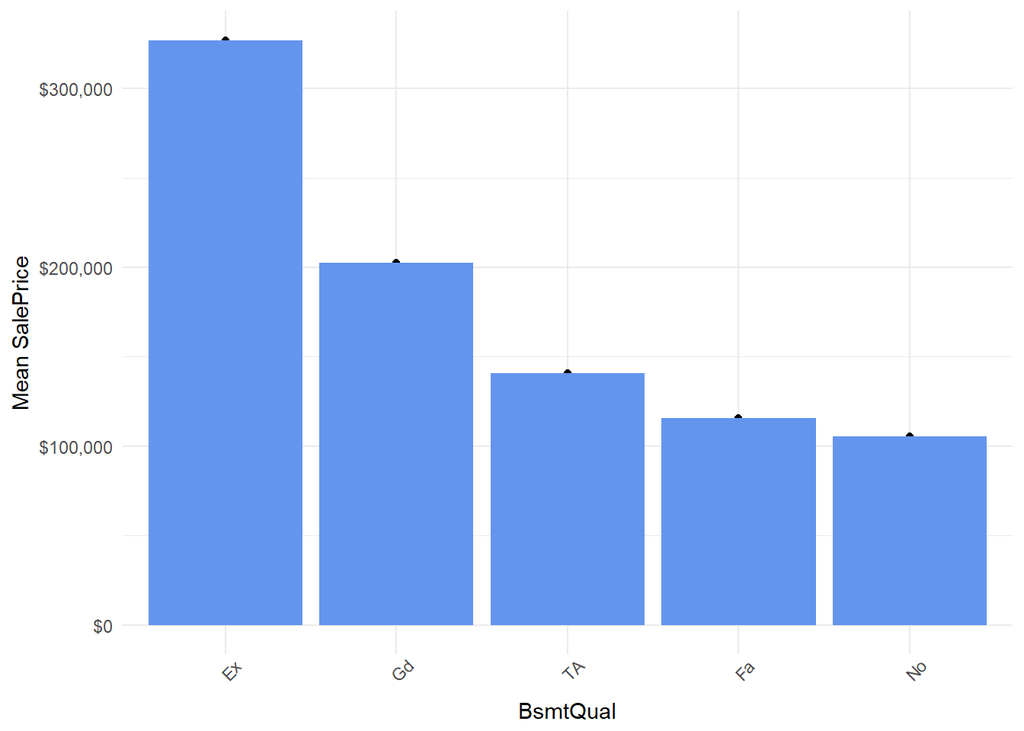

```
##   BsmtQual mean.Quality mean.Price   n
## 1       No         4.30   105652.9  37
## 2       Fa         4.89   115692.0  35
## 3       TA         5.33   140759.8 649
## 4       Gd         6.66   202688.5 618
## 5       Ex         8.26   327041.0 121
```

```r
group.prices('BsmtQual')
```

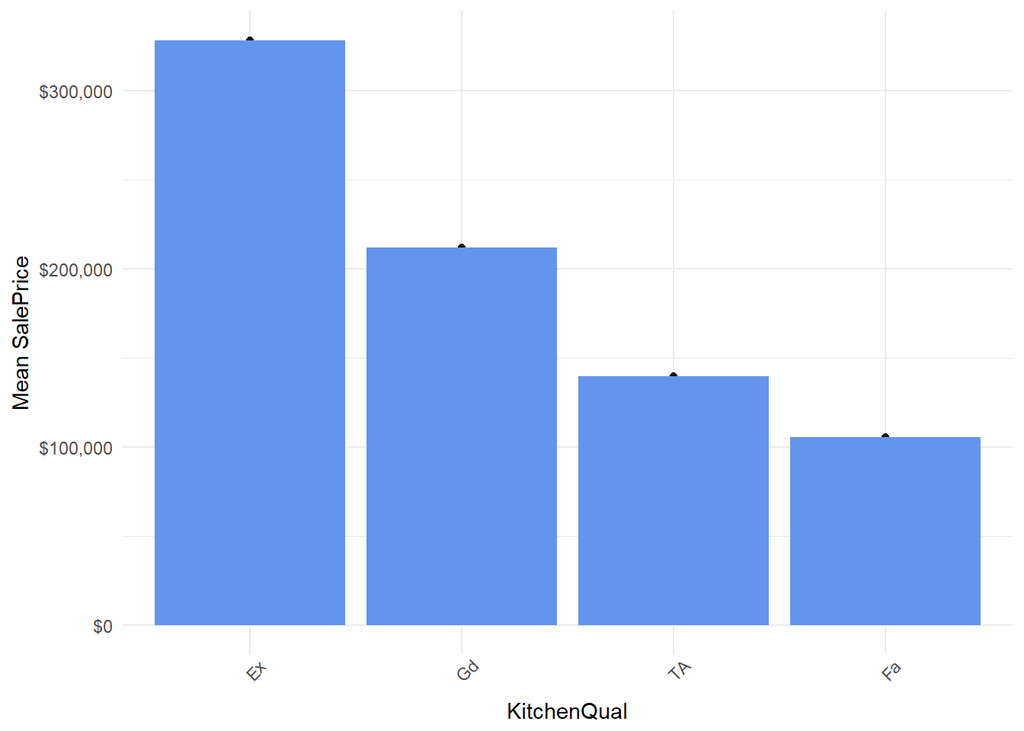

```
##   KitchenQual mean.Quality mean.Price   n
## 1          Fa         4.49   105565.2  39
## 2          TA         5.34   139962.5 735
## 3          Gd         6.79   212116.0 586
## 4          Ex         8.27   328554.7 100
```

```r
group.prices('KitchenQual')
```

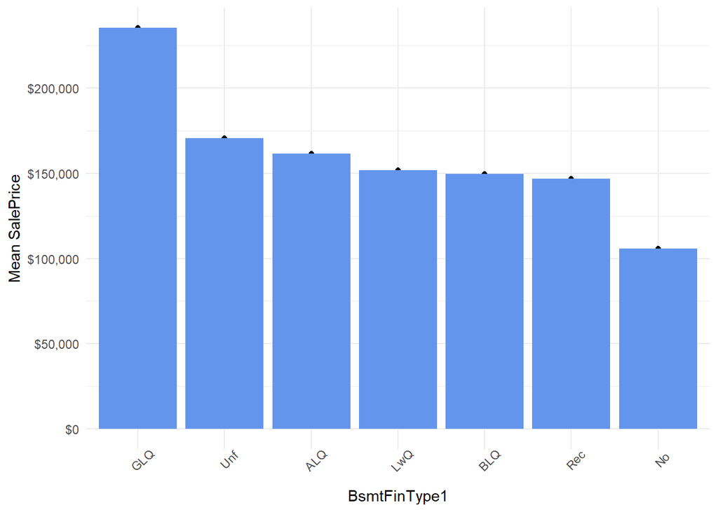

```
##   BsmtFinType1 mean.Quality mean.Price   n
## 1           No         4.30   105652.9  37
## 2          BLQ         5.35   149493.7 148
## 3          Rec         5.35   146889.2 133
## 4          LwQ         5.54   151852.7  74
## 5          ALQ         5.55   161573.1 220
## 6          Unf         6.20   170670.6 430
## 7          GLQ         7.05   235413.7 418
```

```r
qual.list <- c('None' = 0, 'Po' = 1, 'Fa' = 2, 'TA' = 3, 'Gd' = 4, 'Ex' = 5)

both.numeric <- map.fcn(qual.cols, qual.list, both.numeric)

group.prices('BsmtFinType1')
```

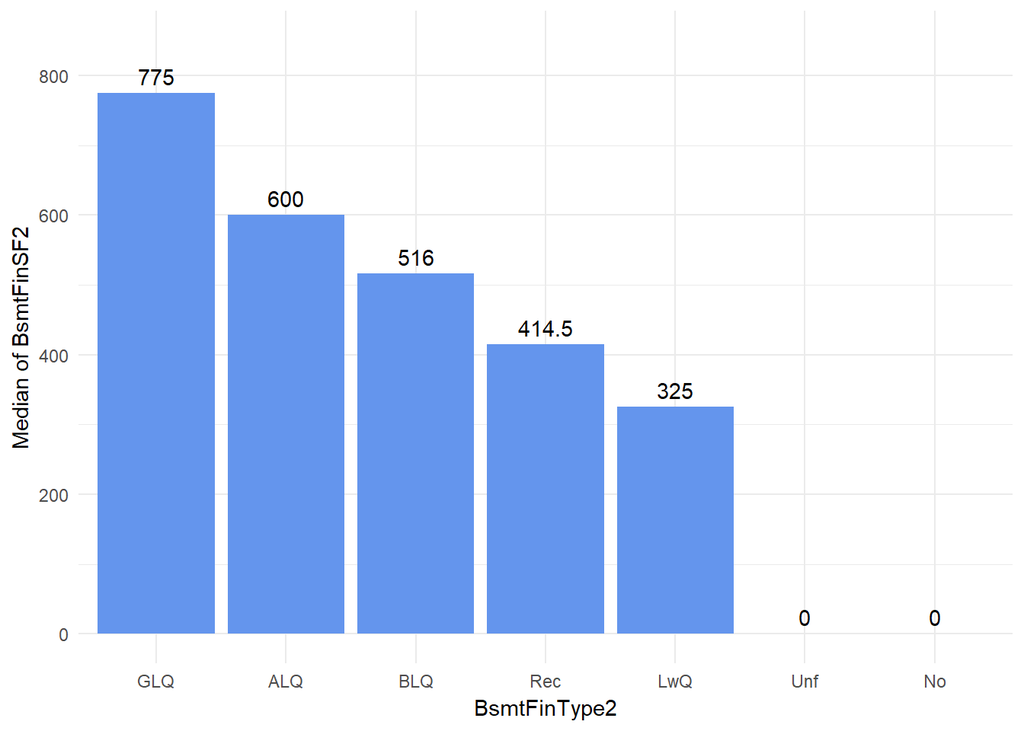

```r
# visualization for BsmtFinTyp2 instead of another table

both[,c('BsmtFinType1', 'BsmtFinSF1')] %>%
  group_by(BsmtFinType1) %>%
  summarise(medianArea = median(BsmtFinSF1), counts = n()) %>%
  arrange(medianArea) %>%
  ggplot(aes(x=reorder(BsmtFinType1,-medianArea), y=medianArea)) +
  geom_bar(stat = 'identity', fill='cornflowerblue') +
  labs(x='BsmtFinType2', y='Median of BsmtFinSF2') +
  geom_text(aes(label = sort(medianArea)), vjust = -0.5) +
  scale_y_continuous(limits = c(0,850)) +
  theme_minimal()
```

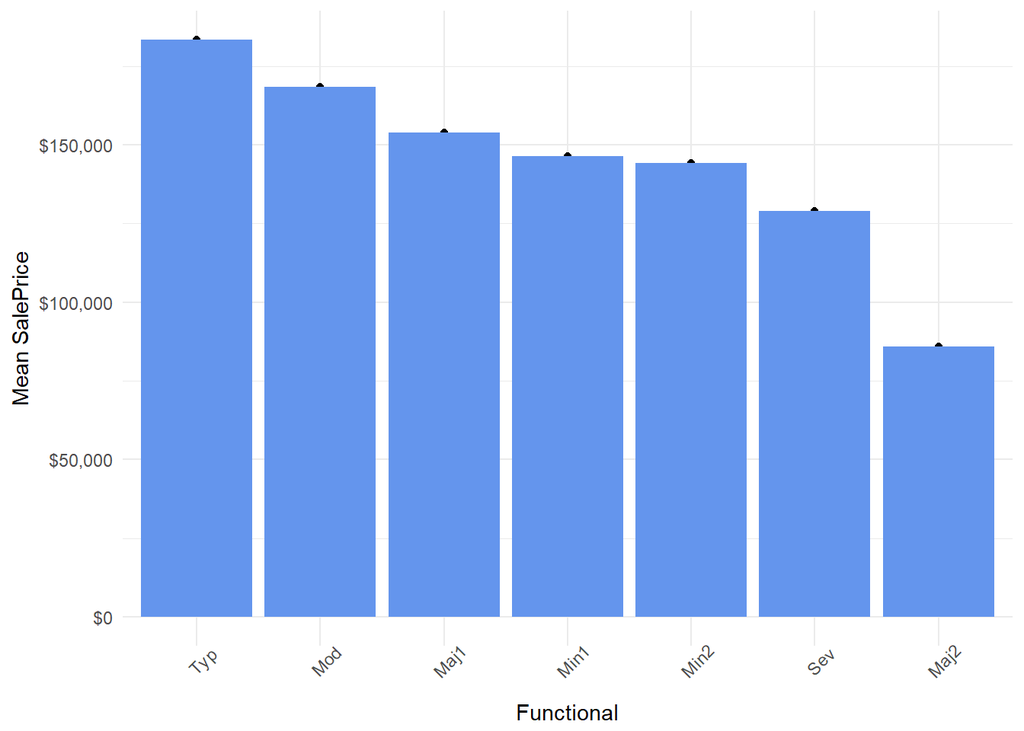

```
##   Functional mean.Quality mean.Price    n
## 1       Min2         4.97   144240.6   34
## 2       Maj2         5.00    85800.0    5
## 3       Min1         5.26   146385.5   31
## 4        Mod         5.40   168393.3   15
## 5       Maj1         5.50   153948.1   14
## 6        Sev         6.00   129000.0    1
## 7        Typ         6.16   183429.1 1360
```

```r
bsmt.fin.list <- c('None' = 0, 'Unf' = 1, 'LwQ' = 2,'Rec'= 3, 'BLQ' = 4, 'ALQ' = 5, 'GLQ' = 6)
both.numeric <- map.fcn(c('BsmtFinType1','BsmtFinType2'), bsmt.fin.list, both.numeric)

group.prices('Functional')
```

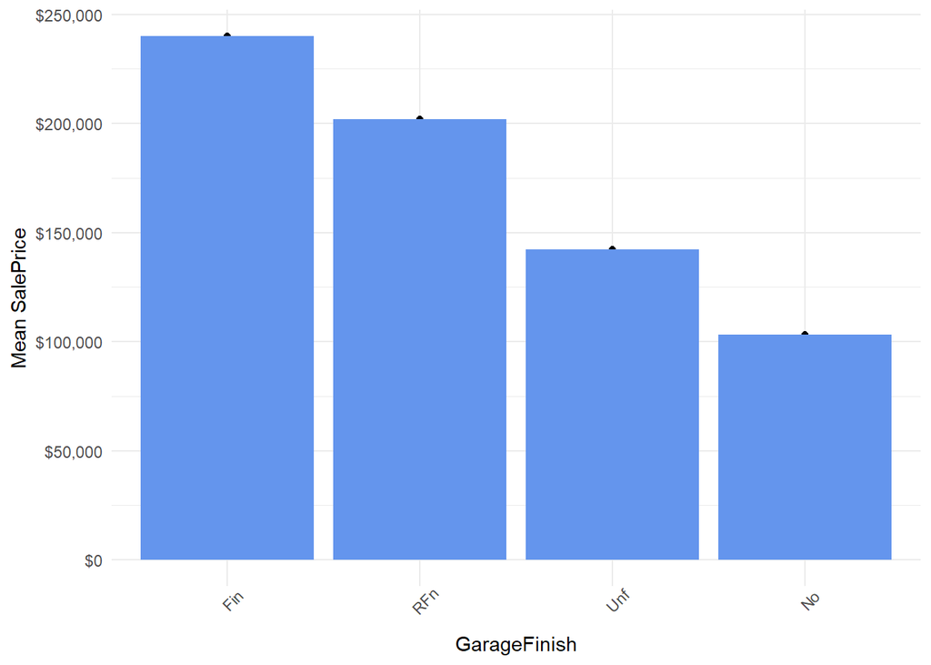

```
##   GarageFinish mean.Quality mean.Price   n
## 1           No         4.60   103317.3  81
## 2          Unf         5.40   142156.4 605
## 3          RFn         6.57   202068.9 422
## 4          Fin         7.07   240052.7 352
```

```r
functional.list <- c('None' = 0, 'Sal' = 1, 'Sev' = 2, 'Maj2' = 3, 'Maj1' = 4, 'Mod' = 5, 'Min2' = 6, 'Min1' = 7, 'Typ'= 8)

both.numeric['Functional'] <- as.numeric(functional.list[both$Functional])

group.prices('GarageFinish')
```

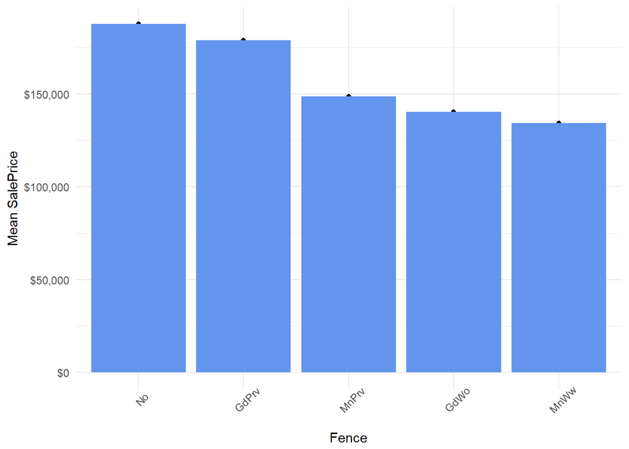

```
##   Fence mean.Quality mean.Price    n
## 1  GdWo         5.17   140379.3   54
## 2  MnWw         5.18   134286.4   11
## 3 MnPrv         5.45   148751.1  157
## 4    No         6.23   187596.8 1179
## 5 GdPrv         6.31   178927.5   59
```

```r
garage.fin.list <- c('None' = 0,'Unf' = 1, 'RFn' = 1, 'Fin' = 2)

both.numeric['GarageFinish'] <- as.numeric(garage.fin.list[both$GarageFinish])

group.prices('Fence')
```

```r
fence.list <- c('None' = 0, 'MnWw' = 1, 'GdWo' = 1, 'MnPrv' = 2, 'GdPrv' = 4)

both.numeric['Fence'] <- as.numeric(fence.list[both$Fence])

MSdwelling.list <- c('20' = 1, '30'= 0, '40' = 0, '45' = 0,'50' = 0, '60' = 1, '70' = 0, '75' = 0, '80' = 0, '85' = 0, '90' = 0, '120' = 1, '150' = 0, '160' = 0, '180' = 0, '190' = 0)

both.numeric['NewerDwelling'] <- as.numeric(MSdwelling.list[as.character(both$MSSubClass)])
```

# Correlation

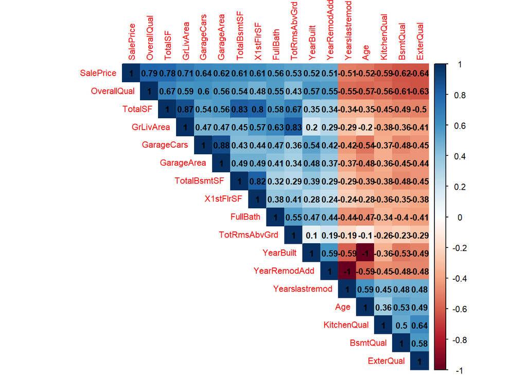

```r
# We need the SalePrice column
corr.train <- cbind(both.numeric[1:1460,], train['SalePrice'])

# Only using the first 1460 rows - training data
correlations <- cor(corr.train)

# Only want the columns that show strong correlations with SalePrice
corr.SalePrice <- as.matrix(sort(correlations[,'SalePrice'], decreasing = TRUE))

corr.idx <- names(which(apply(corr.SalePrice, 1, function(x) (x > 0.5 | x < -0.5))))

corrplot(as.matrix(correlations[corr.idx,corr.idx]), type = 'upper', method='color', addCoef.col = 'black', tl.cex = .7,cl.cex = .7, number.cex=.7)
```

# Redundant variables

We delete redundant variables and the ones with correlation to SalesPrice close to zero

```r
# Neighborhood,TotalBsmtSF, X1stFlrSF, X2ndFlrSF, YearRemodAdd

both = within(both, rm('Neighborhood', 'TotalBsmtSF', 'X1stFlrSF', 'X2ndFlrSF', 'YearRemodAdd'))

# We delete low correlated variables

both = within(both, rm('ExterCond', 'Street', 'MoSold', 'X3SsnPorch', 'BsmtHalfBath', 'MiscVal', 'YrSold'))
```

# Skewness for variables

To facilitate the application of the regression model we are going to eliminate skewness. For numeric feature with excessive skewness, we perform log transformation

```r
column_types <- sapply(names(both),function(x){class(both[[x]])})
numeric_columns <-names(column_types[column_types != "factor"])

# Skew of each variable
skew <- sapply(numeric_columns,function(x){skewness(both[[x]],na.rm = T)})

# We transform all variables above a threshold skewness.
skew <- skew[skew > 0.75]
for(x in names(skew)) {
  both[[x]] <- log(both[[x]] + 1)
}
```

# Dataset separation

```r
training_data = cbind(both[1:1460,], train1["SalePrice"])
test_data = cbind(test1["Id"], both[1461:2919,])
```

# Skewness for Price

Skewness in the Target value

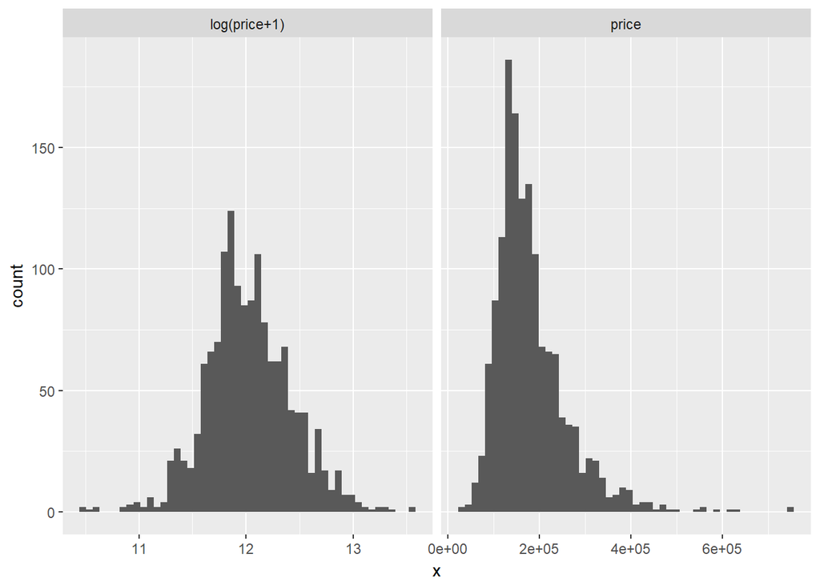

```r
# We get data frame of SalePrice and log(SalePrice + 1) for plotting
df <- rbind(data.frame(version="log(price+1)",x=log(training_data$SalePrice + 1)),
            data.frame(version="price",x=training_data$SalePrice))

ggplot(data=df) +
  facet_wrap(~version,ncol=2,scales="free_x") +
  geom_histogram(aes(x=x), bins = 50)
```

We therefore transform the target value applying log

```r
# Log transform the target for official scoring
training_data$SalePrice <- log1p(training_data$SalePrice)
```

# Train and Validation Spliting

We are going to split the annotated dataset in training and validation for the later evaluation of our regression models

```r
splitdf <- function(dataframe, seed=NULL) {
  if (!is.null(seed)) set.seed(seed)
    index <- 1:nrow(dataframe)
    trainindex <- sample(index, trunc(length(index)/1.5))
    trainset <- dataframe[trainindex, ]
    testset <- dataframe[-trainindex, ]
    list(trainset=trainset,testset=testset)
}
splits <- splitdf(training_data, seed=1)
training <- splits$trainset
validation <- splits$testset
```

# Modelling

We will rank the features according to their predictive power according to this methodologies: the Chi Squared Independence test and the Information Gain.

## Full Model

We must always fit a lm model with all the features to have a baseline to evaluate the impact of the feature engineering. We will place all this code in a function, so we can call it again and again without having to re-write everything. The only thing that changes from one case to another is the dataset that is used to train the model.

```r
lm.model <- function(training_dataset, title) {
  set.seed(121)
  train_control_config <- trainControl(method = "repeatedcv",
                                       number = 5,
                                       repeats = 1,
                                       returnResamp = "all")

  this.model <- train(SalePrice ~ .,
                       data = training_dataset,
                       method = "lm",
                       metric = "RMSE",
                       preProc = c("center", "scale"),
                       trControl=train_control_config)

  for (x in names(validation)) {
    this.model$xlevels[[x]] <- union(this.model$xlevels[[x]], levels(validation[[x]]))
  }
  this.model.pred <- predict(this.model, validation[,-ncol(validation)])
  this.model.pred[is.na(this.model.pred)] <- 0

  my_data <- as.data.frame(cbind(predicted=this.model.pred, observed=validation$SalePrice))
  thismodel.rmse <- sqrt(mean((this.model.pred - validation$SalePrice)^2))

  ggplot(my_data, aes(predicted, observed)) +
    geom_point() + geom_smooth(method = "lm") +
    labs(x="Predicted") +
    ggtitle(ggtitle(paste(title, ': ', format(round(thismodel.rmse, 4), nsmall=4), '; Nr. of features: ',
                          length(training_dataset), sep='')))
}
```

And now, we call the function with all features

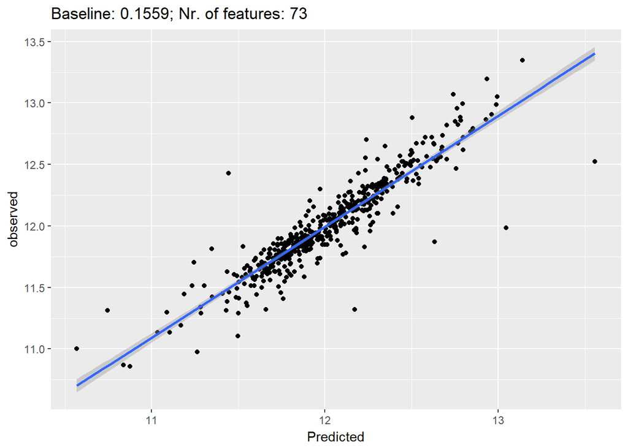

```r
lm.model(training, "Baseline")
```

## Chi-squared Selection

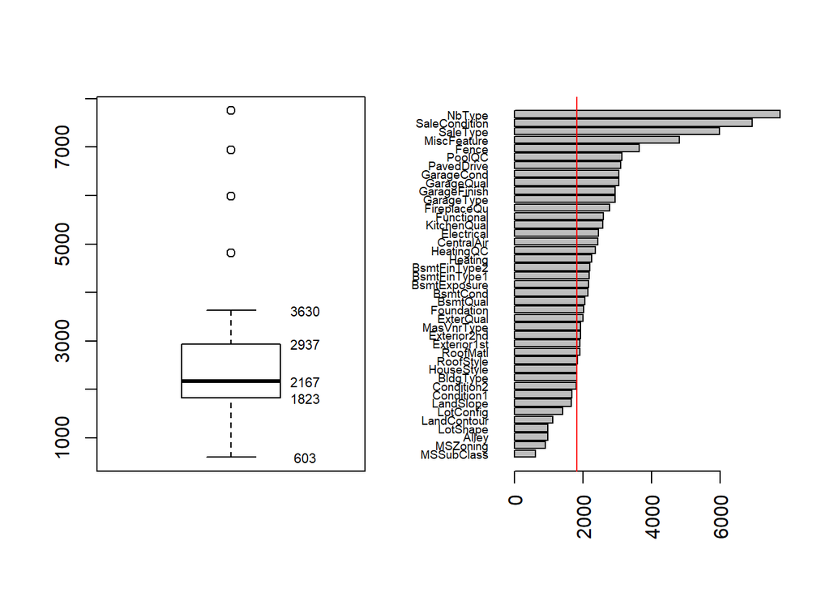

```r
features <- names(training[, sapply(training, is.factor) & colnames(training) != 'SalePrice'])
chisquared <- data.frame(features, statistic = sapply(features, function(x) {
  chisq.test(training$SalePrice, training[[x]])$statistic
}))

par(mfrow=c(1,2))
boxplot(chisquared$statistic)
bp.stats <- as.integer(boxplot.stats(chisquared$statistic)$stats)

chisquared.threshold = bp.stats[2]
text(y = bp.stats, labels = bp.stats, x = 1.3, cex=0.7)
barplot(sort(chisquared$statistic), names.arg = chisquared$features, cex.names = 0.6, las=2, horiz = T)
abline(v=chisquared.threshold, col='red')
```

Now, we can test if this is a good move, by removing any feature with a Chi Squared test statistic against the output below the 1 IQR.

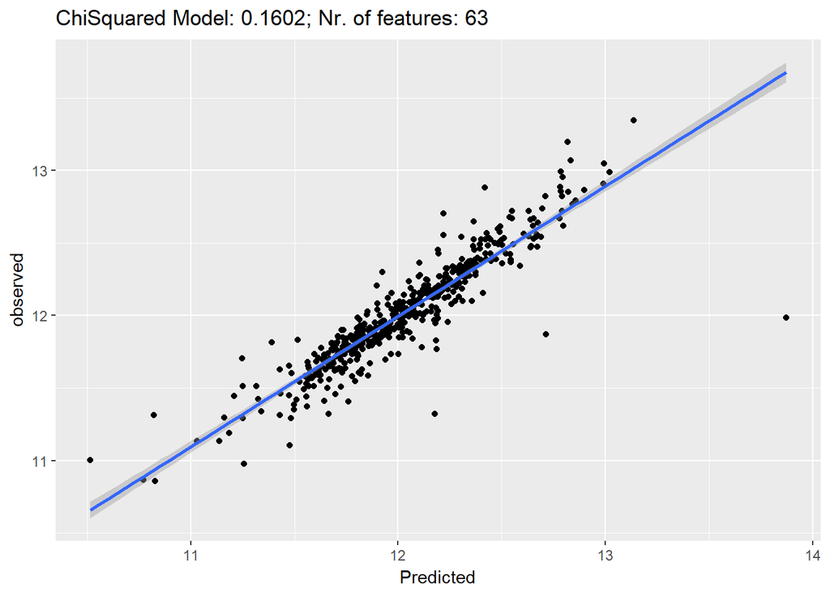

```r
# We determine what features to remove from the training set.
features_to_remove <- as.character(chisquared[chisquared$statistic < chisquared.threshold, "features"])
lm.model(training[!names(training) %in% features_to_remove], "ChiSquared Model")
```

Our model gets worse, so we keep all the current variables.

## Spearman’s correlation.

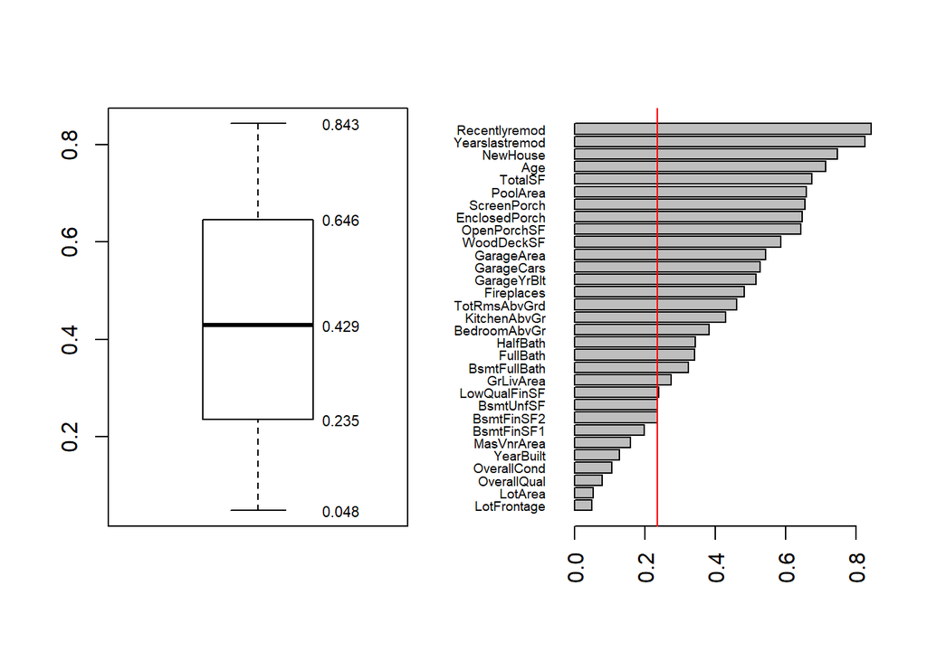

```r
features <- names(training[, sapply(training, is.numeric) & colnames(training) != 'SalePrice'])

spearman <- data.frame(features, statistic = sapply(features, function(x) {
  cor(training$SalePrice, training[[x]], method='spearman')
}))

par(mfrow=c(1,2))
boxplot(abs(spearman$statistic))
bp.stats <- boxplot.stats(abs(spearman$statistic))$stats
text(y = bp.stats,
     labels = sapply(bp.stats, function(x){format(round(x, 3), nsmall=3)}),
     x = 1.3, cex=0.7)

spearman.threshold = bp.stats[2]

barplot(sort(abs(spearman$statistic)), names.arg = spearman$features, cex.names = 0.6, las=2, horiz = T)
abline(v=spearman.threshold, col='red')
```

So, how good is our feature cleaning process? Let’s train the model with the new features, exactly as we did in the Chi Sq. section above.

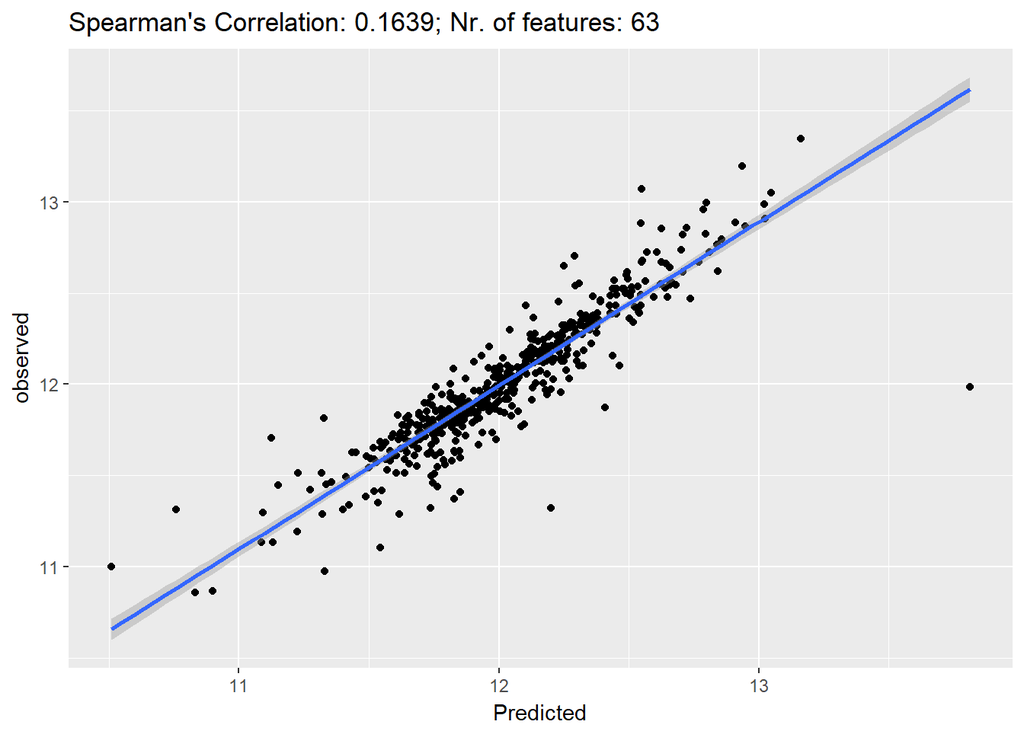

```r
# Determine what features to remove from the training set.
features_to_remove <- as.character(spearman[spearman$statistic < spearman.threshold, "features"])
lm.model(training[!names(training) %in% features_to_remove], "Spearman's Correlation")
```

The model also gets a worse result, so we continue keeping all the current variables.

## Information Gain Selection

We experiment now with Information Gain Selection. This part is equivalent to the Chi Squared, but with another metric.

```r
weights<- data.frame(information.gain(SalePrice~., training_data))
weights$feature <- rownames(weights)
weights[order(weights$attr_importance, decreasing = TRUE),]
```

```
##                attr_importance        feature
## TotalSF            0.543025331        TotalSF
## OverallQual        0.492201116    OverallQual
## GrLivArea          0.382579105      GrLivArea
## NbType             0.349021103         NbType
## GarageCars         0.328153381     GarageCars
## GarageArea         0.321037382     GarageArea
## YearBuilt          0.292232271      YearBuilt
## BsmtQual           0.287010471       BsmtQual
## ExterQual          0.283742148      ExterQual
## Age                0.281232147            Age
## MSSubClass         0.278046092     MSSubClass
## KitchenQual        0.277046037    KitchenQual
## GarageYrBlt        0.255239478    GarageYrBlt
## GarageFinish       0.250110267   GarageFinish
## FullBath           0.233936594       FullBath
## GarageType         0.214417644     GarageType
## Yearslastremod     0.212886054 Yearslastremod
## FireplaceQu        0.196349940    FireplaceQu
## Foundation         0.193365132     Foundation
## TotRmsAbvGrd       0.173120458   TotRmsAbvGrd
## LotFrontage        0.161210439    LotFrontage
## Fireplaces         0.153105972     Fireplaces
## BsmtFinType1       0.151945591   BsmtFinType1
## LotArea            0.144319711        LotArea
## OpenPorchSF        0.143895741    OpenPorchSF
## Exterior1st        0.143090420    Exterior1st
## Exterior2nd        0.140845800    Exterior2nd
## HeatingQC          0.132930489      HeatingQC
## BsmtFinSF1         0.115545225     BsmtFinSF1
## MSZoning           0.111111546       MSZoning
## HouseStyle         0.096955141     HouseStyle
## MasVnrArea         0.095847069     MasVnrArea
## MasVnrType         0.095484996     MasVnrType
## OverallCond        0.085166120    OverallCond
## GarageQual         0.080308571     GarageQual
## WoodDeckSF         0.079805005     WoodDeckSF
## GarageCond         0.076451853     GarageCond
## HalfBath           0.072008475       HalfBath
## BsmtUnfSF          0.070466343      BsmtUnfSF
```

[output cut: 18 more lines]

```
## EnclosedPorch      0.026484221  EnclosedPorch
## LotConfig          0.020610863      LotConfig
## KitchenAbvGr       0.019437401   KitchenAbvGr
## Functional         0.019278065     Functional
## LandContour        0.017587338    LandContour
## Heating            0.016572024        Heating
## ScreenPorch        0.014854951    ScreenPorch
## RoofMatl           0.013542868       RoofMatl
## Condition2         0.010496430     Condition2
## MiscFeature        0.006305680    MiscFeature
## LandSlope          0.005923644      LandSlope
## PoolQC             0.005472276         PoolQC
## BsmtFinSF2         0.000000000     BsmtFinSF2
## LowQualFinSF       0.000000000   LowQualFinSF
## PoolArea           0.000000000       PoolArea
```

```r
information_gain_features <- weights$feature[weights$attr_importance >= 0.05]
```

### Evaluation

We evaluate the impact of the IG selection in the model performance

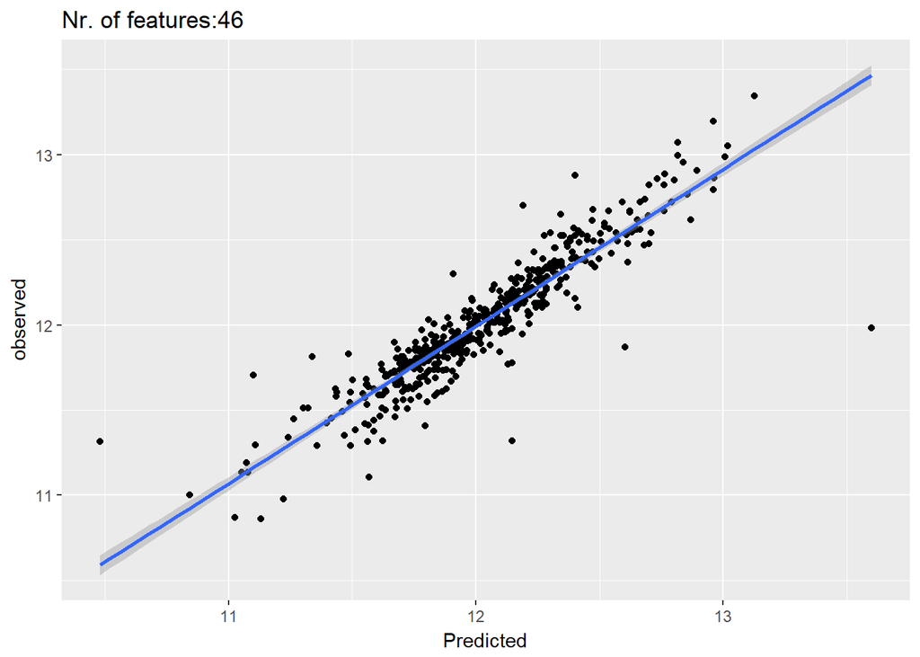

```r
train_control_config <- trainControl(method = "repeatedcv",
                       number = 5,
                       repeats = 1,
                       returnResamp = "all")

ig.lm.mod <- train(SalePrice ~ ., data = training[append(information_gain_features, "SalePrice")],
               method = "lm",
               metric = "RMSE",
               preProc = c("center", "scale"),
               trControl=train_control_config)

for (x in names(validation)) {
  ig.lm.mod$xlevels[[x]] <- union(ig.lm.mod$xlevels[[x]], levels(validation[[x]]))
}
ig.lm.mod.pred <- predict(ig.lm.mod, validation[,-ncol(validation)])
ig.lm.mod.pred[is.na(ig.lm.mod.pred)] <- 0

my_data=as.data.frame(cbind(predicted=ig.lm.mod.pred,observed=validation$SalePrice))

ggplot(my_data,aes(predicted,observed))+
  geom_point() + geom_smooth(method = "lm") +
  labs(x="Predicted") +
  ggtitle(paste('Nr. of features:', length(information_gain_features), sep=''))
```

```r
paste("IG Filtered Linear Regression RMSE = ", sqrt(mean((ig.lm.mod.pred - validation$SalePrice)^2)))
```

```
## [1] "IG Filtered Linear Regression RMSE =  0.155994431876341"
```

Based on these results, we filter the training and validation set with the Information Gain features.

```r
training <- training[append(information_gain_features, "SalePrice")]
validation <- validation[append(information_gain_features, "SalePrice")]
```

## Ridge

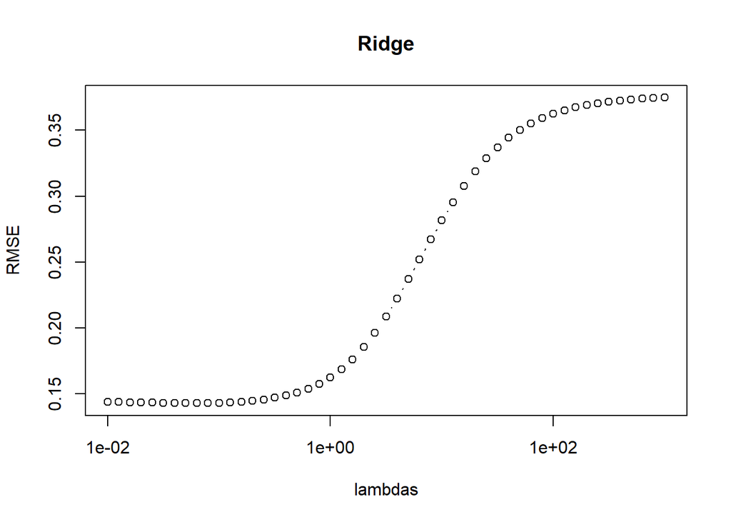

```r
lambdas <- 10^seq(-2, 3, by = .1)
ridge.mod <- glmnet(x = data.matrix(training[,-ncol(training)]), y=training$SalePrice, alpha = 0, lambda = lambdas)

RMSE = numeric(length(lambdas))
for (i in seq_along(lambdas)){
  ridge.pred=predict(ridge.mod, s=lambdas[i], data.matrix(validation[,-ncol(validation)]))
  RMSE[i] <- sqrt(mean((ridge.pred - validation$SalePrice)^2))
}
plot(lambdas, RMSE, main="Ridge", log="x", type = "b")
```

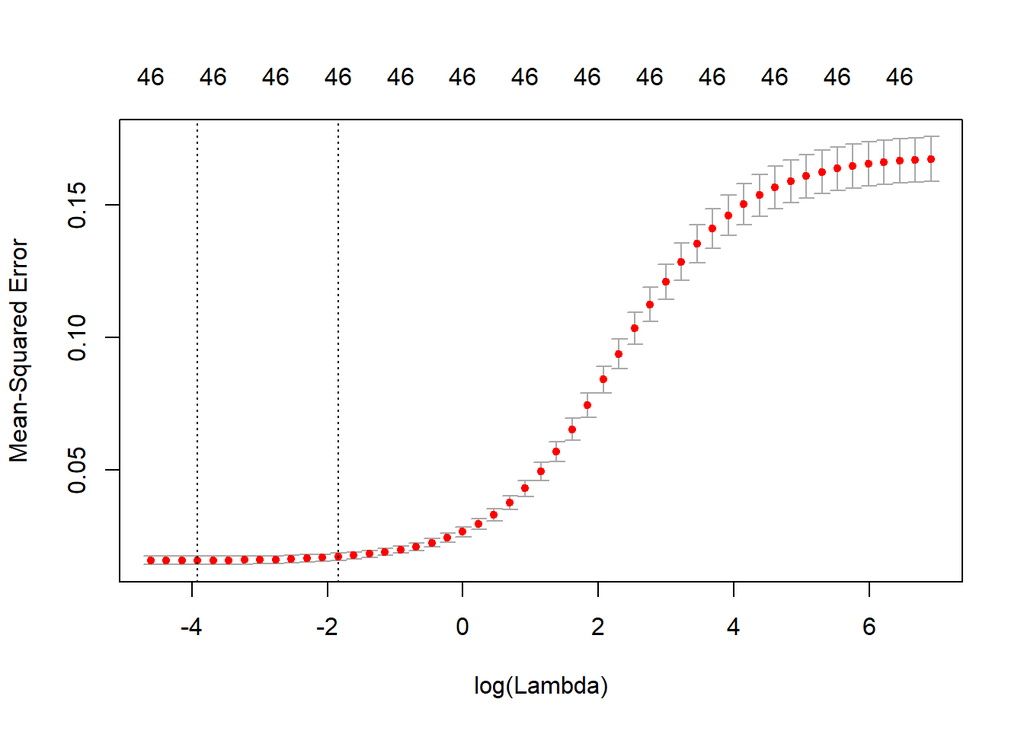

```r
ridge.cv_fit <- cv.glmnet(x = data.matrix(training[,-ncol(training)]), y=training$SalePrice, alpha = 0, lambda = lambdas)
plot(ridge.cv_fit)
```

```r
bestlam <- ridge.cv_fit$lambda.1se
paste("Best Lambda value from CV =", bestlam)
```

```
## [1] "Best Lambda value from CV = 0.158489319246111"
```

```r
ridge.pred <- predict(ridge.mod, s=bestlam, data.matrix(validation[,-ncol(validation)]))
paste("RMSE for lambda ", bestlam, " = ", sqrt(mean((ridge.pred - validation$SalePrice)^2)))
```

```
## [1] "RMSE for lambda  0.158489319246111  =  0.143977840259102"
```

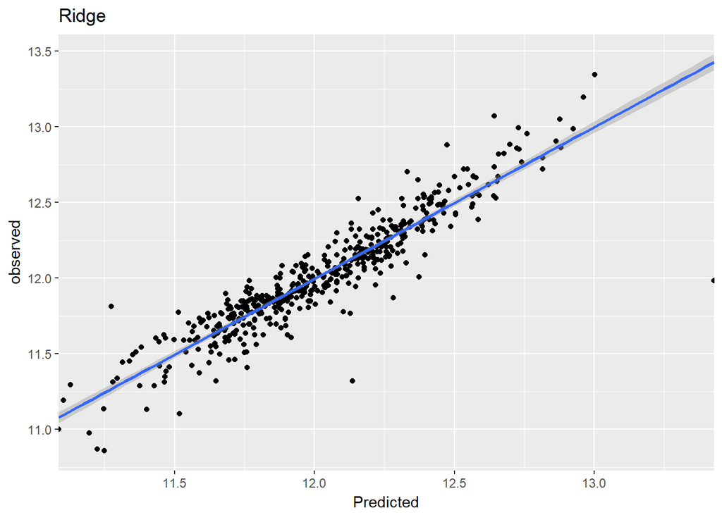

```r
my_data <- as.data.frame(cbind(predicted=ridge.pred, observed=validation$SalePrice))

ggplot(my_data,aes(my_data["1"],observed))+
  geom_point()+geom_smooth(method="lm")+
  scale_x_continuous(expand = c(0,0)) +
  labs(x="Predicted") +
  ggtitle('Ridge')
```

```r
imp <- varImp(ridge.mod, lambda = bestlam)
names <- rownames(imp)[order(imp$Overall, decreasing=TRUE)]
importance <- imp[names,]

data.frame(row.names = names, importance)
```

```
##                  importance
## TotalSF        1.862008e-01
## GrLivArea      1.377535e-01
## CentralAir     9.436647e-02
## TotRmsAbvGrd   8.432637e-02
## LotArea        5.567053e-02
## NbType         4.888457e-02
## LotFrontage    4.130314e-02
## OverallQual    3.958802e-02
## Fireplaces     3.214125e-02
## FullBath       2.984756e-02
## OverallCond    2.800399e-02
## GarageCars     2.726826e-02
## NewHouse       2.375021e-02
## KitchenQual    2.360232e-02
## HalfBath       2.145775e-02
## BsmtQual       1.942748e-02
## SaleCondition  1.630778e-02
## GarageFinish   1.350953e-02
## Foundation     1.282128e-02
## GarageCond     1.274098e-02
## ExterQual      1.241727e-02
## BsmtFinSF1     9.481057e-03
## FireplaceQu    9.293384e-03
## MasVnrType     7.681898e-03
## HeatingQC      7.192233e-03
## BsmtExposure   6.847690e-03
## BsmtCond       5.275033e-03
## BsmtFinType1   4.358651e-03
## WoodDeckSF     4.121353e-03
## LotShape       3.903967e-03
## GarageType     3.486787e-03
## BsmtUnfSF      2.854777e-03
## MSZoning       2.234815e-03
## MasVnrArea     2.096846e-03
## GarageQual     1.831995e-03
## OpenPorchSF    1.599275e-03
## Exterior1st    1.485106e-03
## Exterior2nd    1.441038e-03
## MSSubClass     9.609476e-04
## Yearslastremod 8.954540e-04
## SaleType       7.972043e-04
## HouseStyle     5.858846e-04
## Age            4.403474e-04
## YearBuilt      4.337740e-04
## GarageArea     1.094591e-04
## GarageYrBlt    2.062131e-05
```